# A First Attempt w/ Central Tendency

# Scoring the Game with Objective Functions

Our game requires a winning condition. We will define a winning condition using a mathematical tool called an objective function. Objective functions are the heart and soul of optimization problems: our aim is find an input into the objective function that either maximizes or minimizes the objective function.

In our case we will opt for the category of objective functions called loss or cost functions, where we wish to minimize the output of the function. You can think of this as a scoring system akin to that in golf: the less points you incur during the game the better. Our loss function has to be a function of a players guess and the actual number printed on the ball that is drawn.

Our goal then is to find some guess that minimizes the points we accrue given our loss function. Since we don’t know what the outcome will be in advance, we will borrow from decision theory and search for the guess that minimizes our *expected* loss. We can state this in symbols as follows:

$$g^* = \underset{g}{\operatorname{arg min}} f(g)$$

Where $g^*$ is the optimal guess (the guess that minimizes the loss), $g$ is some guess, and $f$ is some loss function.

The question still remains: what form does our loss function actually take? There are many possibilities, but certain options give rise to new insights regarding our measures of central tendency and how they can help us in our guessing game.

# Inequality Penalty

The first loss function we will explore is perhaps the most simple. We get 1 point for guessing incorrectly and 0 points for guessing correctly (again, or goal is to get the fewest points possibility). We can refer to this as an inequality penalty.

In symbols:

$$d(g,x) = 1_{\{g\space\not=\space x\}}$$
Where $d(g,x)$ is the inequality penalty function given a guess $g$ and outcome $x$, and $1_{\{g\space\not=\space x\}}$ is an indicator function returning $1$ if $g\space\not=\space x$ and $0$ otherwise.

We actually want to take an expectation over all possible outcomes, so we can write the expected penalty for a given guess $g$ as:

$$E[d(g,X)] = \sum_{i=1}^nd(g,x_i)P(x_i) = \sum_{i=1}^n1_{\{g\space\not=\space x_i\}}P(x_i)$$

As the expectation of an indicator function is the probability of the condition contained within the indicator function, we can actually reduce our expected penalty to:

$$E[d(g,X)] = P(X \not = g) = 1 - P(X = g)$$

So we now have our inequality penalty function, and we can compute its expectation for a given guess. What guess minimizes this penalty? Let’s examine it numerically and visually:

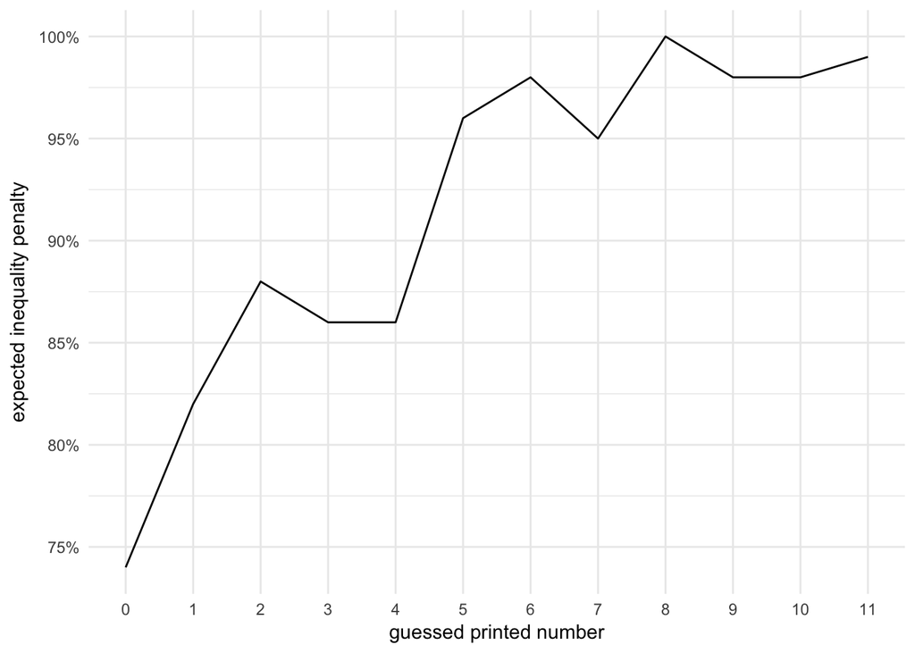

```r
possible_guesses <- min(balls):max(balls)

expected_inequality_penalties <- map_dbl(possible_guesses, function(current_guess){

  mean(current_guess != balls)

})

ggplot() +
  geom_line(aes(x = possible_guesses, y = expected_inequality_penalties)) +
  scale_y_continuous(labels = percent, breaks = seq(0,1,.05)) +
  scale_x_continuous(breaks = min(balls):max(balls)) +
  labs(x = 'guessed printed number', y = 'expected inequality penalty') +
  theme_minimal() +
  theme(panel.grid.minor.x = element_blank())
```

The penalty is minimized at the guess of $0$, which is the mode of our distribution. The relationship should be apparent: the penalty associated with the guess $g$ is the compliment of the probability the printed number will be $g$. Because probabilities are bounded between $0$ and $1$ our minimization problem has an equivalent maximization problem:

$$g^* = \underset{g}{\operatorname{arg min}} P(X \not= g) = \underset{g}{\operatorname{arg max}} P(X = g) = Mode(X)$$

To minimize the probability that the guess is wrong we have to maximize the probability the guess is right. The printed number that has the highest probability of occurring is by definition the mode. When our scoring system only cares whether we were exactly right, we ought to choose the mode as our best guess; but what if we give ourselves some credit for guesses that are near the printed number actually drawn?

# Absolute Difference Penalty

An alternative penalty function is that of the absolute difference between our guess and the actual outcome. This will gives us some credit for making guesses that are close to the actual outcome. For example, if we were to guess 5, and the outcome were 3, we would receive 2 points. If our guess was 2 and the outcome were 3, we would receive 1 point. In symbols:

$$d(g,x) = |g-x|$$

Again, we wish to take an expectation of this loss function.

$$E[d(g,X)] = E(|g-X|) = \sum_{i=1}^n |g-x_i|P(x_i)$$

What guess will minimize the expectation of our loss function? Let’s find out numerically:

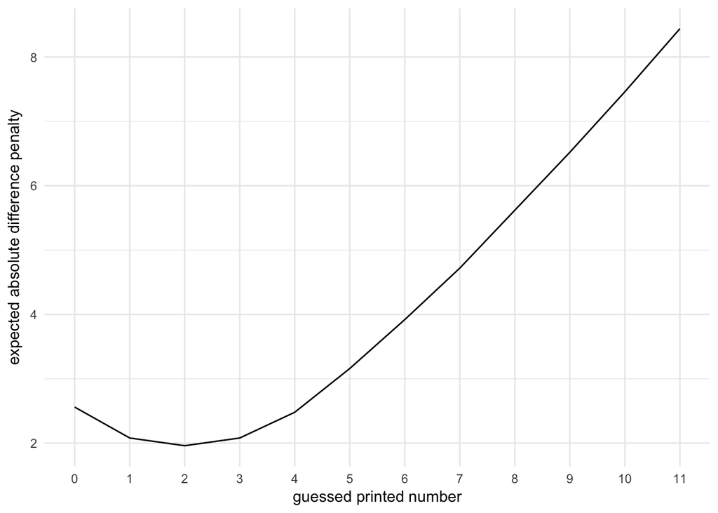

```r
possible_guesses <- min(balls):max(balls)

expected_abs_diff_penalties <- map_dbl(possible_guesses, function(current_guess){

  mean(abs(current_guess - balls))

})

ggplot() +
  geom_line(aes(x = possible_guesses, y = expected_abs_diff_penalties)) +
  # scale_y_continuous(labels = percent, breaks = seq(0,1,.05)) +
  scale_x_continuous(breaks = min(balls):max(balls)) +
  labs(x = 'guessed printed number', y = 'expected absolute difference penalty') +
  theme_minimal() +
  theme(panel.grid.minor.x = element_blank())
```

Our absolute difference penalty finds its minimum at 2, which is the median of our distribution. Why is this so? Why does the median minimize the absolute difference penalty? Let’s see if we can build an intuition.

Let’s begin by sorting the balls by their printed number.

```r
sorted_balls <- sort(balls)

print(sorted_balls)
```

```
##   [1]  0  0  0  0  0  0  0  0  0  0  0  0  0  0  0  0  0  0  0  0  0  0  0
##  [24]  0  0  0  1  1  1  1  1  1  1  1  1  1  1  1  1  1  1  1  1  1  2  2
##  [47]  2  2  2  2  2  2  2  2  2  2  3  3  3  3  3  3  3  3  3  3  3  3  3
##  [70]  3  4  4  4  4  4  4  4  4  4  4  4  4  4  4  5  5  5  5  6  6  7  7
##  [93]  7  7  7  9  9 10 10 11
```

Next, let’s examine the penalty for every ball if we guess a specific number, say 3.

```r
abs(sorted_balls - 3)
```

```
##   [1] 3 3 3 3 3 3 3 3 3 3 3 3 3 3 3 3 3 3 3 3 3 3 3 3 3 3 2 2 2 2 2 2 2 2 2
##  [36] 2 2 2 2 2 2 2 2 2 1 1 1 1 1 1 1 1 1 1 1 1 0 0 0 0 0 0 0 0 0 0 0 0 0 0
##  [71] 1 1 1 1 1 1 1 1 1 1 1 1 1 1 2 2 2 2 3 3 4 4 4 4 4 6 6 7 7 8
```

Rather than looking at the absolute differences that our penalty provides, let’s instead look at just the differences.

```r
sorted_balls - 3
```

```
##   [1] -3 -3 -3 -3 -3 -3 -3 -3 -3 -3 -3 -3 -3 -3 -3 -3 -3 -3 -3 -3 -3 -3 -3
##  [24] -3 -3 -3 -2 -2 -2 -2 -2 -2 -2 -2 -2 -2 -2 -2 -2 -2 -2 -2 -2 -2 -1 -1
##  [47] -1 -1 -1 -1 -1 -1 -1 -1 -1 -1  0  0  0  0  0  0  0  0  0  0  0  0  0
##  [70]  0  1  1  1  1  1  1  1  1  1  1  1  1  1  1  2  2  2  2  3  3  4  4
##  [93]  4  4  4  6  6  7  7  8
```

We can see that any outcomes less than our guess is negative, any outcome above our value is positive, and any value equal to our guess is 0. Let’s focus just on the sign of the differences.

```r
sign(sorted_balls - 3)
```

```
##   [1] -1 -1 -1 -1 -1 -1 -1 -1 -1 -1 -1 -1 -1 -1 -1 -1 -1 -1 -1 -1 -1 -1 -1
##  [24] -1 -1 -1 -1 -1 -1 -1 -1 -1 -1 -1 -1 -1 -1 -1 -1 -1 -1 -1 -1 -1 -1 -1
##  [47] -1 -1 -1 -1 -1 -1 -1 -1 -1 -1  0  0  0  0  0  0  0  0  0  0  0  0  0
##  [70]  0  1  1  1  1  1  1  1  1  1  1  1  1  1  1  1  1  1  1  1  1  1  1
##  [93]  1  1  1  1  1  1  1  1
```

We can tally the occurrence of each sign given our guess.

```r
table(sign(sorted_balls - 3))
```

```
##
## -1  0  1
## 56 14 30
```

We can see that there are 56 negative values and 30 positive values given our guess of 3. What if we were guess a larger number?

```r
table(sign(sorted_balls - 6))
```

```
##
## -1  0  1
## 88  2 10
```

The count of negative signs increase and the count of positive signs decrease. What if we were to guess a smaller number?

```r
table(sign(sorted_balls - 1))
```

```
##
## -1  0  1
## 26 18 56
```

The count of positive signs increase and the count of negative signs decrease. Let’s look at this graphically for all possible guesses.

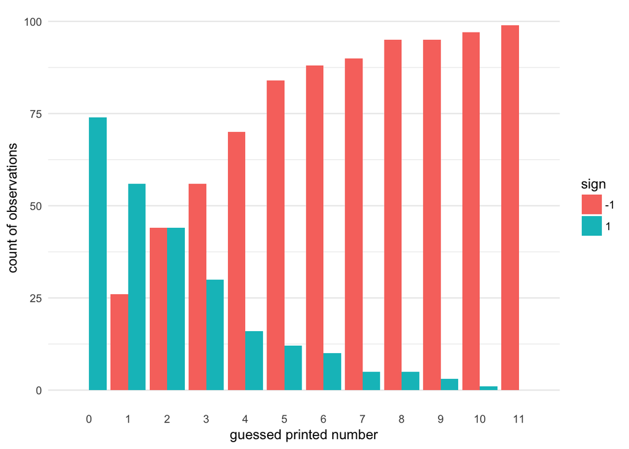

```r
map_df(possible_guesses, function(current_guess){

  table(sign(sorted_balls - current_guess)) %>%
    tibble(sign = names(.), total = ., guess = current_guess)

}) %>%
  filter(sign != 0) %>%
  left_join(expand.grid(sign = .$sign, guess = .$guess), ., by = c('sign','guess')) %>%
  mutate(total = if_else(is.na(total), 0L, total)) %>%
  ggplot() +
  geom_col(aes(x = guess, y = total, fill = sign), position = 'dodge') +
  scale_x_continuous(breaks = min(balls):max(balls)) +
  labs(x = 'guessed printed number', y = 'count of observations') +
  theme_minimal() +
  theme(panel.grid.minor.x = element_blank(),
        panel.grid.major.x = element_blank())
```

We see here that as our guess moves to the right of the median, the count of negative signs increases. The opposite is true as our guess moves to the left of the median. When we guess the median, the number of negative and positive signs is equal. As a guess, the median perfectly balances the number of negative and positive differences.

# Squared Difference Penalty

We have seen how the mode and the median are optimal given an inequality and absolute difference penalty respectively. What role does the mean play? The answer arises when we wish to penalize larger errors worse than smaller errors.

Let’s imagine that we want to give ourselves more credit when we are very near to the right answer, but penalize ourselves when we are very far. One way to do this would be to take the squared differences between our guess and the actual outcome. For example, if we guess $2$, and the result is $3$, we get $1^2=1$ point; if we guess $2$ and the result is $4$ we get $2^2=4$ points, and if we guess $2$ and the result is $10$ we get $8^2 = 64$ points. It becomes much more more important to avoid large errors.

Here is our cost function in symbols:

$$d(g,x) = (g-x)^2$$

As per usual, we would like to take this as an expectation.

$$E[d(g,X)] = E[(g-X)^2] = \sum_{i=1}^n (g-x_i)^2P(x_i)$$

Let’s find the minimum of this cost function numerically and visually:

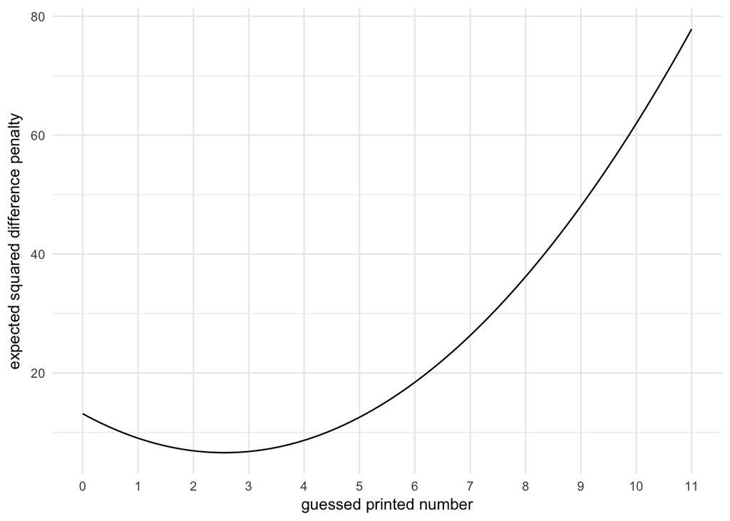

```r
possible_guesses <- seq(min(balls), max(balls),.01)

expected_sqr_diff_penalties <- map_dbl(possible_guesses, function(current_guess){

  mean((current_guess - balls)^2)

})

ggplot() +
  geom_line(aes(x = possible_guesses, y = expected_sqr_diff_penalties)) +
  # scale_y_continuous(labels = percent, breaks = seq(0,1,.05)) +
  scale_x_continuous(breaks = min(balls):max(balls)) +
  labs(x = 'guessed printed number', y = 'expected squared difference penalty') +
  theme_minimal() +
  theme(panel.grid.minor.x = element_blank())
```

The expected squared difference penalty bottoms out at 2.56, which is the mean of our distribution. An analytic derivation of the mean as a solution to squared distances can be found [on stack exchange](https://math.stackexchange.com/questions/2554243/understanding-the-mean-minimizes-the-mean-squared-error). We won’t cover the details here.

So the mean is the best guess when were are being penalized by the squared difference between our guess and the actual outcome. We now can associate each of the three most common measures of central tendency as being the best guess given some scoring system that penalizes us for guessing incorrectly. In this way we see measures of central tendency as solutions to variational problems, a concept taken from the calculus of variations.

# Lp metrics

Before we close,we should touch on the common thread that spans all three of the cost functions we discussed: the concept of Lp metrics.

All of our cost functions discussed so far are special cases of a more general form:
$$d(g,x) = |g-x|^p$$

We will refer to this general form as an Lp metric. We note here that Lp metrics are actually far more general than what we will cover in this post, and will be a recurring topic as we dive deeper into machine learning in particular. For now though, we will continue to discuss the form we have just described.

Each of our cost functions is a special case of the general form. When $p = 1$, we get the absolute difference penalty. When $p = 2$, we get the squared difference penalty. We define the limit $p \to 0$ as the inequality penalty. In this way, as $p$ gets smaller we begin to treat any difference as being equally bad, whereas when $p$ gets larger bigger differences matter much much more. What happens when $p \to \infty$?

Let’s demonstrate what happens in R:

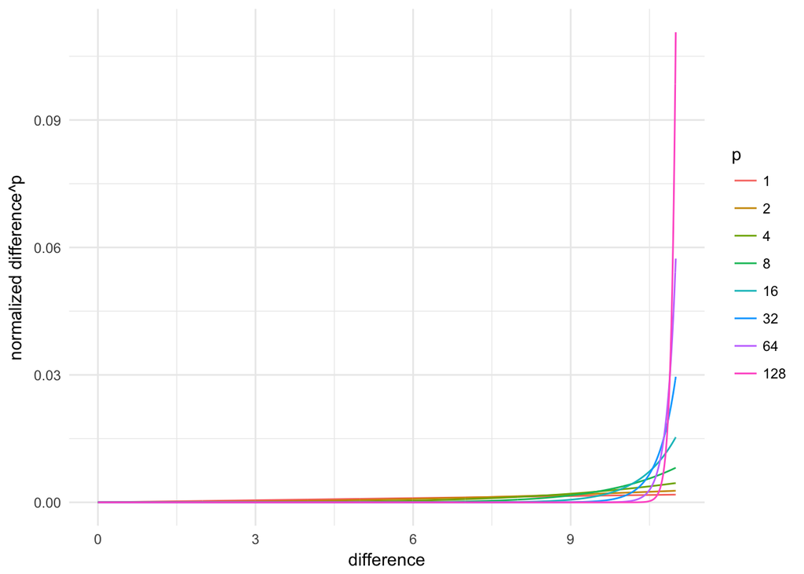

```r
map_df(c(2^c(0:7)), function(p){

 tibble(x = seq(0,11,.01), y = x^p, p = p)

}) %>%
  group_by(p) %>%
  mutate(y = y/sum(y)) %>%
  ggplot() +
  geom_line(aes(x = x, y = y, color = factor(p))) +
  theme_minimal() +
  scale_color_discrete(name = 'p') +
  labs(x = 'difference', y = 'normalized difference^p')
```

On the x axis we have the absolute value of the difference between a guess and an actual outcome. On the y axis we have difference raised to a power $p$. The y axis has been normalized so that we can see all of the lines together. From here the trend as $p \to \infty$ is quite apparent: only the largest differences matter. What this results in is a penalty function that gives as many points as the maximum difference:

$$E[d(g,X)] = max|g-X|$$

What value minimizes this extreme cost function?

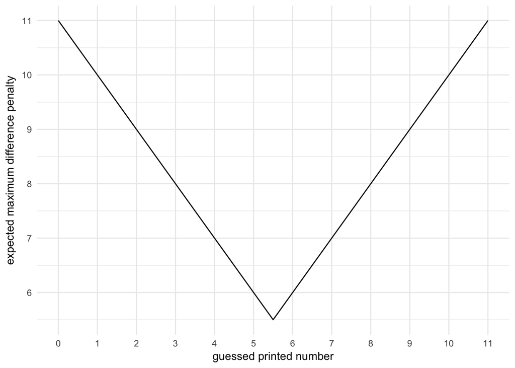

```r
possible_guesses <- seq(min(balls),max(balls),.01)

expected_max_diff_penalties <- map_dbl(possible_guesses, function(current_guess){

  max(abs(current_guess - balls))

})

ggplot() +
  geom_line(aes(x = possible_guesses, y = expected_max_diff_penalties)) +
  # scale_y_continuous(labels = percent, breaks = seq(0,1,.05)) +
  scale_x_continuous(breaks = min(balls):max(balls)) +
  labs(x = 'guessed printed number', y = 'expected maximum difference penalty') +
  theme_minimal() +
  theme(panel.grid.minor.x = element_blank())
```

The expected maximum difference penalty bottoms out when we guess the number that is halfway between our minimum and maximum value i.e. the midrange. When we want to minimize the single largest difference we ought to choose the midrange. This is an extreme cost function, and one that has a severe limitation: the maximum and the minimum of the possible outcomes must be defined. While this works fine for our current guessing game, it is impossible to compute when talking about a probability distribution missing an upper or lower bound.

# Aftermath

We covered a lot of ground in this post, but here is a brief recap:

- The mean, median, and mode are all measures of central tendency: numbers that represent typical values in a data set.
- When trying to make a good guess using a measure of central tendency, we have to know how we are defining success i.e. what is the penalty if we make a mistake?
- Use the mode when minimizing the penalty for inequality; use the median when minimizing the absolute difference penalty; use the mean when minimizing the squared difference penalty; and use the midrange (if it exists) when minimizing the maximum difference penalty.

Often we will come across problems when cost functions are ill defined (if at all), and we don’t have complete knowledge of the outcomes or their probabilities. This makes the problem of guessing well replete with challenges that we will need to build an arsenal of tools to solve.

That’s all for now. More on this later, also expect this post to get revised and refined!